# DiamondsAppPresentation

David Conejero  
28 de agosto de 2017

### Diamonds App

Predict quick and easily if the price they are offering you adjusts to the market Price.

This application allows you to check if the value of a diamods is adjusted to the value in the market. You just need to set up the Quality of the cut, the caret and the price, and you will be able to see the adjusted prices for that quality and if, according to the model, your diamond is too cheap, too expensive or it is adjusted to the regular market price.

### Input

There are three inputs on the left side panel to control:

- The Cut Quality (selection)
- Carey (slidebar)
- Price (sidebar)

### Visualization

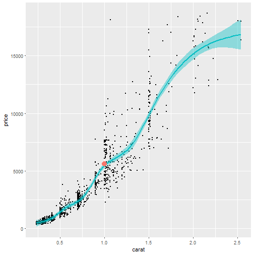